# Tworzenie aplikacji w programie Shiny

Wydział Nauk Ekonomicznych UW

Piotr Ćwiakowski, Piotr Wójcik

Do czego służy pakiet Shiny? Głównym zadaniem Shiny jest budowa interaktywnych aplikacji internetowych, w których w prosty i elegancki sposób możemy zaprezentować analizowane dane.

[Galeria aplikacji Shiny](http://shiny.rstudio.com/gallery/)

## 1. Podstawowe informacje

### 1.1. Instalacja pakietu:

```
install.packages('shiny')
```

### 1.2. Konstrukcja aplikacji

Każda aplikacja Shiny wymaga utworzenia dwóch plików: ui.R oraz server.R

ui.R odpowiada za wszystkie elementy związane z interfejsem użytkownika:

- wprowadzanie danych, które zależą od akcji użytkownika (input)
- wyświetlanie obiektów
- wygląd i struktura aplikacji

server.R odpowiada za tworzenie obiektów i wykonywanie obliczeń:

- przekazywanie obiektów do interfejsu (output)
- odpowiednik konsoli w R Studio

##### Bazowa konstrukcja pliku ui.R i server.R:

###### ui.R

```
shinyUI(fluidPage(
))
```

###### server.R

```
shinyServer(function(input, output) {
})
```

##### .

Stwórzmy pliki ui.R oraz server.R i zapiszmy je w jednym folderze. W tym momencie stworzyliśmy naszą pierwszą aplikację.

Jak ją uruchomić?

   ```
   runApp(appDir='sciezka_do_folderu_aplikacji', launch.browser = TRUE/FALSE)
   ```

Zwróćmy uwagę, że możliwe jest otwarcie tylko jednej aktywnej aplikacji. Uruchamiamy nasz program. Naszym oczom ukazuje biała strona internetowa - nic dziwnego - stworzyliśmy pustą aplikację.

Nauczymy się teraz dodawać elementy do naszej aplikacji. Każda aplikacja shiny składa się ze składowych - prostokątnych paneli.

#### Panel tytułowy.

Tworzymy dodając do pliku `ui.R` następujący kod:

ui.R

```
shinyUI(fluidPage(

  titlePanel("To jest tytul!")

))
```

Dodajmy kolorowe tło, aby przekonać się, że panel istotnie ma postać prostokątną:

ui.R

```
shinyUI(fluidPage(

  div(titlePanel("To jest tytul!"), style="background-color: #e6f2ff;")

))
```

#### Układ: pasek boczny i pasek główny.

Oprócz panelu tytułowego istnieje możliwość utworzenia aplikacji o następującej strukturze:

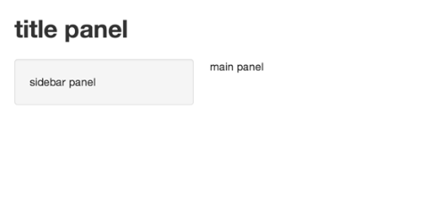

Czyli dodajemy dwa panele: panel boczny i panel główny. Tworzymy je umieszczając w funkcji sidebarLayout, dwie funkcje otwierające: `sidebarPanel` i `mainPanel.`

ui.R

```
shinyUI(fluidPage(

  titlePanel("Tu jest Tytul!"),

  sidebarLayout(

    sidebarPanel(
        # tu dodajemy obiekty pobierające dane
    ),

    mainPanel(
        # tu wyświetlamy wyniki
    )
  )
))
```

Możemy także umieścić pasek boczny po prawej stronie:

ui.R

```
shinyUI(fluidPage(

  titlePanel("Tu jest Tytul!"),

  sidebarLayout(position="right",

    sidebarPanel(
        # tu dodajemy obiekty pobierające dane
    ),

    mainPanel(
        # tu wyswietlamy wyniki
    )
  )
))
```

> **Ćwiczenie 1:**

Utwórz aplikację złożoną z trzech paneli (tytułowy, boczny i główny). Wprowadź do nich dowolne wartości i pozmieniaj kolory każdego z paneli.

## 2. Wypełnianie paneli

Gdy mamy utworzone panele najwyższy czas zacząć wypełniać je obiektami. Wnętrze każdego z paneli stanowi pewną stronę internetową. Konstrukcja wnętrza panelu powinna więc być możliwa przy pomocy języka html. Dokładnie tą zasadą kieruje się shiny. Umożliwia on dodawanie html poprzez tzw. *HTML Tags*. Jest to grupa funkcji służących do wprowadzania kodu htmlowego.

Zasady działania:

- Nazwa tagu odpowiada nazwie znacznika w języku HTML, np. tag h1() odpowiada znacznikowi `<h1> </h1>` w HTML. Nie ma więc potrzeby zamykać danego znacznika.
- Aby zastosować daną funkcję musimy ją pobrać z listy tags poprzez `tags$nazwa_tagu()`  
  **Uwaga!** Część funkcji nie wymaga pobierania jej z listy. Możemy więc odwoływać się do tagu bezpośrednio. Są to: p, h1, h2, h3, h4, h5, h6, a, br, div, span, pre, code, img, strong, em, hr. Pełna lista *HTML Tags* wraz z opisem działania znajduje się pod linkiem: http://shiny.rstudio.com/articles/tag-glossary.html.
- W celu wprowadzenia tekstu między znaczniki HTMl, musimy wprowadzić go między cudzysłowie wewnątrz danego tagu. Przykład:  
  `<h1>To jest nagłówek</h1>` jest równoważny h1(“To jest nagłówek”).
- Znaczniki HTML posiadają dodatkowe atrybuty (niekiedy opcjonalne). Przykładowo, aby umieścić na stronie internetowej obrazek piszemy:  
  `<img src="sciezka_do_zdjęcia"></img>`  
  . W HTML tags wystarczy podać dany atrybut jako argument funkcji:  
  `img(src="sciezka_do_zdjęcia")`
- Aby sprawdzić jaki kod HTML generuje dany tag, wystarczy wczytać pakiet ‘Shiny’ i wpisać tag - wraz z zawartością - do konsoli RStudio.
- Aby umiescić dwa tagi wewnątrz innego oddzielamy je przecinkiem, np. `p(strong("Pogrubiony "), em(pochylony))` co da nam: `<p><strong>Pogrubiony</strong><em>pochylony</em></p>`

> **Ćwiczenie 2:**

Wprowadź za pomocą HTML tags kod:

```
<h1 style='color:blue'>Nagłówek!</h1>
```

oraz

```
<em><strong>Pogrubiony</strong><sup>Indeks górny</sup></em>
```

Poprawność rozwiązania sprawdź wpisując wynik do konsoli R.

> **Ćwiczenie 3:**

Wprowadź za pomocą HTML tags kod: `<strong>Pogrubiony</strong><sup>Indeks górny</sup>`. Wskazówka: zbadaj działanie funkcji tagList.

Opiszemy część najczęściej stosowanych tagów w aplikacjach Shiny:

- a  
  Tworzy odnośnik do danej strony internetowej. Głównym atrybutem jest href, będący ścieżką danej strony internetowej.  
  `a(href="link_do_strony", Wyświetlany_tekst)`
- strong  
  Pogrubia tekst.  
  `tags$strong("Takst który chcemy pogrubić.")`
- br  
  Odpowiada za złamanie linii. Stosujemy nie podając argumentu.  
  `br()`
- blockquote  
  Tworzy cytat. Dodatkowym argumentem jest `cite`, który jest źródłem danego cytatu.  
  `tags$blockquote("Oto cytat.", cite="Żródło.")`
- code  
  Wyświetla źródło kodu komputerowego.  
  `tags$code("Ten tekst zostanie wyświetlony jako kod komputerowy.")`
- div  
  Jeden z najważniejszych znaczników HTML. Zaznacza blok tekstu umożliwiając jego identyfikację, przez co mamy możliwość edycji bloku przy pomocy CSS. Posiada trzy podstawowe atrybuty: class - nazwa klasy, pod którą ma być pamiętany blok id - nazwa identyfikatora, którym ma być oznaczony blok style - atrybut będący wewnętrznym kodem CSS  
  `div("BLOK_KODU_HTML", class="nazwa_klasy", id="nazwa_id", style="kod_CSS")`
- em  
  Pochylenie tekstu.  
  `tags$em("Tekst_do_pochylenia")`
- h1, h2, h3, h4, h5, h6  
  Nagłówki. Im niższy numer tym nagłówek jest bardziej nadrzędny.  
  `h1("Tekst.")`
- hr  
  Tworzy poziomą linię.  
  `hr()`
- img  
  Umieszcza obrazek na stronie. Powszechne atrybuty to: src - źródło zdjęcia width/height - szerokość i wysokość obrazka  
  `tags$img(src = "www.rstudio.com", width = "100px", height = "100px")`
- ol oraz li  
  Tworzy listę uporządkowaną. ol - otwiera liste, li - tworzy wypunktowania.  
  `tags$ol( li("Punkt_1"), li("Punkt_2"), li("Punkt_3") )`
- ul oraz li  
  Tworzy listę nieuporządkowaną. Działanie jak w poprzednim punkcie.
- p  
  Tworzy nowy akapit tekstu.  
  `p("Tekst.")`
- span  
  Działa podobnie do div, z tą różnicą, że zaznacza fragmenty kody, a nie całe bloki.
- sup oraz sub  
  Indeks górny i dolny.

Aby sprawdzić działanie pozostałych tagów i pełną listę atrybutów, polecamy stronę W3Schools

**Zadanie 1.** Poniższy tekst zawiera źródło pewnej strony internetowej (aby zobaczyć jej zawartość przepisz poniższy kod do notatnika i zapisz plik z rozszerzeniem .html). Przepisz kod źródłowy tej strony przy użyciu HTML tags, do pustego skryptu R, a następnie uruchom te skrypt. Czy otrzymałeś ten sam kod co w treści zadania?

*Wskazówka:* Nie przejmuj się, że w konsoli R nie wyświetla się tytuł strony z sekcji nagłówka - to tzw. metadane strony - i domyślnie nie wyświetlają się użytkownikowi (ale są skanowane przez google i mają wpływ na pozycjonowanie strony).

```
<html>
<head>
 <title>To jest tytuł mojej strony.
 </title>
</head>
<body>
 <p>
  <h1>Oto nagłówek nowoutworzonego akapitu</h1>
  Poprzez znacznik <strong>p</strong> utworzyłem nowy akapit mojej strony internetowej.
  Tekst ten znajduje się więc w nowym akapicie, który tworzy osobny blok strony.<br> Mogę tu umieszczać tekst w
dowolnym formacie: <em>pochylony</em>, w indeksie <sup>górnym</sup>, czy <sub>dolnym</sub>. Tekst mogę także
<span style="color:red">kolorować</span> <span style="color:blue">w</span> <span
style="color:#b2f456">dowolny</span> <span style="color:#f123bf">sposób</span>.
 </p>
<hr>
 <p>
 <h2 align='right'>Oto nagłówek niższego rzędu, który rozpoczyna drugi akapit</h2>
  Akapit może zawierać nie tylko tekst. Umieśćmy w nim obrazek: <img src='https://www.rstudio.com/wp-
content/uploads/2014/07/RStudio-Logo-Blue-Gradient.png' width='10%'><br>
  Co więcej mamy możliwość utworzenia tabelki:<br>
   <table border='1'>
   <tr>
    <td>1
    </td>
    <td>2
    </td>
    <td>3
    </td>
   </tr>
   <tr>
    <td>4
    </td>
    <td>5
    </td>
    <td>6
    </td>
   </tr>
   </table>
 </p>
</body>
</html>
```

**Przykład:**

Pogrubimy tekst w panelu tytułowym, dodamy listę wypunktowaną w panelu bocznym i dodamy obrazek w głównym:

```
shinyUI(fluidPage(

  titlePanel(strong("Pogrubiony tekst w tytule!")),

  sidebarLayout(position="right",

                sidebarPanel(
                  tags$ul(
                      tags$li("Punkt 1"),
                      tags$li("Punkt 2"),
                      tags$li("Punkt 3")
                  )
                ),

                mainPanel(
                  tags$img(src="https://upload.wikimedia.org/wikipedia/commons/d/d9/Black_cherry_tree_histogram.svg", width="60%")
                )
  )
))
```

**Zadanie 2.**

Napisz aplikację, która w panelu tytułowym zawiera pochylony tekst. W panelu bocznym umieść listę uporządkowaną zawierającą linki do wybranych przez Ciebie stron internetowych. W panelu głównym umieść nagłówki każdego poziomu, przy czym każdy poziom zaznacz tekstem różnego koloru. Uwaga! Aby pokolorować nagłówek na dany kolor ustawiamy atrybut `style` danego nagłówka następująco: `style = "color:nazwa_koloru;"`

Wszystko co udało nam się do tej pory utworzyć nie uwzględniało żadnych elementów interaktywnych. Wprowadźmy do naszej aplikacji interakcję z użytkownikiem - an początek przez interfejs pobierający dnae.

## 3. Control widgets

### 3.1. Pobieranie informacji (control widgets)

Aplikacje Shiny są interaktywne, a więc umożliwiają użytkownikowi wpływać na jej działanie. Aplikacja pobiera od użytkownika wartości pewnych zmiennych, aby przetwarzać je na działanie aplikacji. Mamy następujące narzędzia do pobierania danych (tzw. *control widgets*):

| function | widget |
| --- | --- |
| actionButton | Przycisk akcji |
| checkboxGroupInput | Grupa przycisków typu checkbox |
| checkboxInput | Pojedynczy checkbox |
| dateInput | Kalendarz (do wyboru dat) |
| dateRangeInput | Dwa kalendarze do wyboru zakresu dat |
| fileInput | Wczytywanie plików z dysku do programu |
| helpText | Umieszczanie tekstu z opisem na stronie |
| numericInput | Wprowadzanie danych numerycznych (z klawiatury) |
| radioButtons | Przyciski “wyboru”“ |
| selectInput | Lista rozwijana |
| sliderInput | Suwak |
| submitButton | Przycisk zatwierdzania |
| textInput | Pole do wprowadzania tekstu |

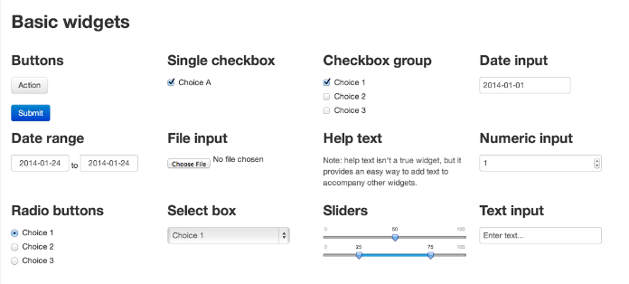

#### submitButton

**Wysyła zmienne pobrane poprzez control widgets do pliku server.R. Gdy nie został użyty w panelu aplikacji, zmienne wysyłane są na bieżąco, niezwłocznie po wprowadzeniu (może przeciążać działanie aplikacji).**  
**Użycie:**  
`submitButton(text = "Apply Changes", icon = NULL, width = NULL)`  
**Argumenty:**

- text - nagłówek przycisku
- icon - ikona, która pojawi się na przycisku. Ikonę wywołujemy przy pomocy funkcji:

  ```
  icon(name, lib = "font-awesome")
  ```

  gdzie name to nazwa ikony, a lib to biblioteka z, której pobieramy ikonę. Mamy do wyboru dwie biblioteki, font-awesone oraz glyphicon.  
  Zobacz: [Font Awesome](http://fontawesome.io/icons/), [Glyphicons](http://getbootstrap.com/components/#glyphicons)  
  Uwaga! Gdy zdefiniowaliśmy bibliotekę, nie musimy wpisywać nazwy ikony wywołując ją.
- width - szerokość przycisku (możliwe jednostki: px, %, em, pt, in, cm, mm, ex, or pc; gdy nie podano brany domyślnie px).

##### **Przykład:**

###### ui.R

```
fluidPage(
  titlePanel("submitButton przykład"),
  sidebarLayout(
   sidebarPanel(
    textInput("text", label="Wprowadź tekst", value="tekst domyślny"),
    submitButton("Zaakceptuj", icon = icon("hand-right", lib="glyphicon")
    )),
   mainPanel(
      verbatimTextOutput("text")
    )
  )
)
```

###### server.R

```
function(input, output) {
  output$text <- renderText({
    paste("Wprowadzony tekst to:", input$text)
  })
}
```

##### .

> **Ćwiczenie 4:**

Przetestuj powyższy przykład konfigurując wedle własnego uznania: tekst wyświetlany na przycisku, jego szerokość, oraz ikonę z wybranej przez Ciebie biblioteki.

##### **Przykład bardziej rozbudowany:**

###### ui.R

```
fluidPage(
  titlePanel("submitButton przykład"),
  sidebarLayout(
   sidebarPanel(
    sliderInput("n", "N:", min = 10, max = 1000, value = 200,
                step = 10),
    textInput("text", "Text:", "text here"),
    submitButton("Zaakceptuj", icon = icon("hand-right", lib="glyphicon")
    )),
   mainPanel(
      plotOutput("plot1", width = 400, height = 300),
      verbatimTextOutput("text")
    )
  )
)
```

###### server.R

```
function(input, output) {
  output$plot1 <- renderPlot({
    hist(rnorm(input$n))
  })

  output$text <- renderText({
    paste("Wprowadzony tekst to:", input$text)
  })
}
```

##### .

#### actionButton

**Przycisk, który zlicza ilość jego kliknięć.**  
**Użycie:**  
`actionButton(inputId, label, icon = NULL, width = NULL)`  
**Argumenty:**

- inputId - zmienna pod której nazwą pamiętana jest ilość wciśnięć,
- label - napis znajdujący się na przycisku,
- icon - ikona, która pojawi się na przycisku,
- width - szerokość przycisku

##### **Przykład:**

###### ui.R

```
fluidPage(
  titlePanel("actionButton przykład"),
  sidebarLayout(
   sidebarPanel(
     actionButton("przycisk", label="Zobacz efekt", icon=icon("plus", lib="font-awesome"), width='40%')
   ),
   mainPanel(
    "Liczba wciśnięć wynosi: ", textOutput("liczba")
   )
  )
)
```

###### server.R

```
function(input, output) {
  output$liczba <- renderText({
    input$przycisk
  })
}
```

##### .

> **Ćwiczenie 5:**

Wykorzystaj powyższy przykład (edytując parametr width) w celu przetestowania różnych jednostek długości. Sprawdź, czy licznik kliknięć wyzeruje się po odświeżeniu strony.

#### checkboxInput

**Tworzy checkbox, którego zaznaczenie/odznaczenie powoduje wysłanie do serwera zmienną logiczną TRUE/FALSE**  
**Użycie:**  
`checkboxInput(inputId, label, value = FALSE, width = NULL)`  
**Argumenty:**

- inputId - zmienna, która będzie przechowywać TRUE lub FALSE,
- label - etykieta widżetu,
- value - wartość domyślna (gdy TRUE, checkbox będzie zaznaczony),
- width - szerokość obszaru checkboxa (np. ‘400px’ lub ‘30%’).

##### **Przykład:**

###### ui.R

```
fluidPage(
  titlePanel("checkboxInput przykład"),
  sidebarLayout(
   sidebarPanel(
    checkboxInput("tf", label="Czy brać zmienną pod uwagę?", value=FALSE)
   ),
  mainPanel(
    textOutput("tresc")
  )
 )
)
```

###### server.R

```
function(input, output) {
  output$tresc <- renderText({
    paste("Twój wybór to:", input$tf)
  })
}
```

##### .

> **Ćwiczenie 6:**

W powyższym przykładzie przekonaliśmy się, że zaznaczenie chceckboxa zwraca nam wartość TRUE, a odznaczenie - FALSE. Zmodyfikuj powyższy kod tak, aby zaznaczenie checkboxa wyświetlało nam FALSE, a odznaczenie - TRUE.

#### numericInput

**Tworzy pole, do którego możemy wprowadzić pewną wartość liczbową.**  
**Użycie:**  
`numericInput(inputId, label, value, min = NA, max = NA, step = NA, width = NULL)`  
**Argumenty:**

- inputId - zmienna przechowująca wprowadzoną liczbę,
- min - najmniejsza możliwa do wprowadzenia liczba,
- max - największa możliwa do wprowadzenia liczba,
- step - krok przechodzenia od min do max,
- label - etykieta widżetu,
- value - wartość domyślna,
- width - szerokość pola.

##### **Przykład:**

###### ui.R

```
fluidPage(
  titlePanel("numericInput przykład"),
  sidebarLayout(
   sidebarPanel(
    numericInput("en", label="Wprowadź liczbę", value=0, min=1, max=1000, step=1)
   ),
  mainPanel(
    textOutput("tresc")
  )
 )
)
```

###### server.R

```
function(input, output) {
  output$tresc <- renderText({
    paste("Wylosowano wektor długości ",input$en,", próbek z rozkładu normalnego N(0,1).")
  })
  output$srednia <- renderText({
    paste("Średnia wynosi:", mean(rnorm(input$en)))
  })
}
```

##### .

> **Ćwiczenie 7:**

Przetestuj powyższą aplikację pod kątem wprowadzania niedozwolonych wartości. Następnie przetestuj na wybranych przez Ciebie wartościach, działanie parametrów min, max i step. Co jeśli wprowadzimy min>max?

##### **Przykład wykorzystania numericInput do sprawdzania dokładności średniej z próbki o rozkładzie N(0,1):**

###### ui.R

```
fluidPage(
  titlePanel("numericInput przykład"),
  sidebarLayout(
   sidebarPanel(
    numericInput("en", label="Wprowadź wielkość próbki", value=0, min=1, max=1000,     step=1)
   ),
  mainPanel(
    textOutput("tresc"),
    textOutput("srednia")
  )
 )
)
```

###### server.R

```
function(input, output) {
  output$tresc <- renderText({
    paste("Wylosowano wektor długości ",input$en,", próbek z rozkładu normalnego N(0,1).")
  })
  output$srednia <- renderText({
    paste("Średnia wynosi:", mean(rnorm(input$en)))
  })
}
```

##### .

#### sliderInput

**Pobiera liczbę lub zakres liczb poprzez ich wybór (przy pomocy znacznika) na pasku osi. Umożliwia także wybór dat.**  
**Użycie:**  
`sliderInput(inputId, label, min, max, value, step = NULL, round = FALSE, ticks = TRUE, animate = FALSE, width = NULL,`  
`sep = ",", pre = NULL, post = NULL, timeFormat = NULL, timezone = NULL, dragRange = TRUE)`  
**Argumenty:**

- inputId - zmienna przechowująca wybraną liczbę (gdy zdefiniowano wybór przedziału zwróci listę zawierającą jego końce),
- label - etykieta widżetu,
- min - dolny zakres paska
- max - górny zakres paska
- value - wartość domyślna (gdy podana jako wektor dwuliczbowy, automatycznie traktuje pasek jako wybierający przedział)
- step - krok wartości, które może przyjmować znacznik,
- round - przyjmuje wartości całkowite. Oznacza dziesiętny stopień zaokrąglania wartości,
- ticks - czy pokazywać podziałkę na pasku (TRUE lub FALSE),
- animate - TRUE jeśli chcemy wprowadzić animację wyboru, FALSE - jeśli nie chcemy. Jest także opcja wprowadzania własnej animacji: patrz ??animationOptions.
- width - szerokość paska,
- sep - czy wprowadzić separator tysięcy,
- pre - prefiks, który chcemy wprowadzić przy wartości,
- post - suffiks, który chcemy wprowadzić przy wartości,
- timeFormat - format czasowy, gdy pasek zawiera Datę,
- timezone - strefa czasowa (w przypadku formatu POSIXt),
- dragRange - opcja dostępna tylko gdy wybieramy przedział. Gdy TRUE umożliwia, poprzez przeciągnięcie środka wybranego przedziału, na przesunięcie jego granic.

##### **Przykład wyboru przedziału wartości:**

###### ui.R

```
fluidPage(
  titlePanel("sliderInput przykład"),
  sidebarLayout(
   sidebarPanel(
    sliderInput("przedzial", label="Wybierz przedział wartości", value=c(0,1), min=-10, max=10, step=1)
   ),
  mainPanel(
    textOutput("przed")
  )
 )
)
```

###### server.R

```
function(input, output) {
 output$przed<-renderText(paste("Wybrałeś przedział: ", input$przedzial[[1]], " - ", input$przedzial[[2]]))
}
```

##### .

> **Ćwiczenie 8:**

Przetestuj działanie parametrów: min, max, step, ticks, pre, post i drag Range. Sprawdź w jaki sposób zmieni się pasek, gdy podamy pojedynczą wartość parametru ‘value’. Co się stanie, gdy podamy wektor długości 3?

#### selectInput

**Tworzy listę wyboru.**  
**Użycie:**  
`selectInput(inputId, label, choices, selected = NULL, multiple = FALSE, selectize = TRUE, width = NULL, size = NULL)`  
**Argumenty:**

- inputId - zmienna przechowująca wybraną wartość, bądź listę wartości,
- label - etykieta widżetu,
- choices - lista wartości, z której pobieramy dane do wyboru. Jeśli lista zawiera nazwy, są one wyświetlane zamiast wartości. Np. `choices=c("A"=1,"B"=2)`, sprawi, że użytkownik będzie miał do wyboru “A” lub “B”, natomiast wartości wysyłane do serwera będą odpowiednio równe 1 lub 2,
- selected - wartość wybrana domyślnie,
- multiple - czy możliwy jest wybór wielokrotny,
- selectize - jeśli TRUE, wykorzystuje do listy wyboru skrypt js: selectize.js, który zmienia wizualny wygląd widżetu,
- width - szerokość listy,
- size - liczba elementów widocznych do wyboru w liście.

##### **Przykład:**

###### ui.R

```
fluidPage(
  titlePanel("selectInput przykład"),
  sidebarLayout(
   sidebarPanel(
    selectInput("slowo", label="Wybierz zwierzę", choices = c("Pies" = 1, "Kot" = 2, "Mysz" = 3), selected=1)
   ),
  mainPanel(
    textOutput("wynik")
  )
 )
)
```

###### server.R

```
function(input, output) {
 output$wynik<-renderPrint({input$slowo})
}
```

##### .

> **Ćwiczenie 9:**

Zbadaj działanie parametrów multiple, selectize i size. Co się zmieni, gdy w parametrze choices usuniemy nazwy współrzędnych?

#### checkboxGroupInput

**Tworzy grupę checkbox-ów, zwracając wektor wartości logicznych w zależności od dokonanego wyboru.**  
**Użycie:**  
`checkboxGroupInput(inputId, label, choices, selected = NULL, inline = FALSE, width = NULL)`  
**Argumenty:**

- inputId - zmienna, która będzie przechowywać TRUE lub FALSE,
- label - etykieta widżetu,
- width - szerokość checkbox-ów (np. ‘400px’ lub ‘30%’),
- choices - lista wartości, z której będą pobierane dane poprzez checkboxy. Jeśli lista zawiera nazwy, są one wyświetlane przy boxach zamiast przesyłanych wartości. Długość tej listy odpowiada ilości checkbox-ów,
- selected - wartości, które mają być zaznaczone domyślnie,
- inline - jeśli TRUE boxy są ułożone w poziomie.

##### **Przykład:**

###### ui.R

```
fluidPage(
  titlePanel("checkboxGroupInput przykład"),
  sidebarLayout(
   sidebarPanel(
    checkboxGroupInput("slowo", label="Wybierz zwierzę", choices = c("Pies" = 1, "Kot" = 2, "Mysz" = 3, "Kanarek" = 4), selected=1)
   ),
  mainPanel(
    textOutput("wynik")
  )
 )
)
```

###### server.R

```
function(input, output) {
 output$wynik<-renderPrint({input$slowo})
}
```

##### .

> **Ćwiczenie 10:**

Zbadaj działanie parametrów width oraz inline. Co się zmieni, gdy w parametrze choices usuniemy nazwy współrzędnych?

#### textInput

**Tworzy okno pobierające tekst.**  
**Użycie:**  
`textInput(inputId, label, value = "", width = NULL, placeholder = NULL)`  
**Argumenty:**

- inputId - zmienna przechowująca pobrany tekst,
- label - etykieta widżetu,
- value - wartość domyślna,
- width - szerokość okna,
- placeholder - informacja pomocnicza wyświetlana w pustym okienku.

##### **Przykład:**

###### ui.R

```
fluidPage(
  titlePanel("textInput przykład"),
  sidebarLayout(
   sidebarPanel(
    textInput("slowo", label="Wprowadź tekst", value="Nie wprowadzono żadnego tekstu.")
   ),
  mainPanel(
    textOutput("wynik")
  )
 )
)
```

###### server.R

```
function(input, output) {
 output$wynik<-renderText({input$slowo})
}
```

##### .

> **Ćwiczenie 11:**

Zbadaj działanie parametru placeholder.

##### **Przykład wykorzystujący powyższe widżety:**

###### ui.R

```
fluidPage(
  titlePanel("Wielomiany i ich pochodne"),
  sidebarLayout(
   sidebarPanel(
    selectInput("en", label="Wprowadź wykładnik potęgi", choices = 1:10, selected=1),
    checkboxGroupInput("pochodna", label="Czy wyświetlić:", c("Drugą pochodną?" = 2,"Pierwszą pochodną?" = 1)),
    sliderInput("przedzial", label="Wybierz przedział argumentów", min=-10, max=10, value=c(-10,10), step=1),
    textInput("kom", label="Wprowadź komentarz.")
  ),
   mainPanel(
    plotOutput("wykres"),
    textOutput("komentarz")
  )
 )
)
```

###### server.R

```
function(input, output) {

  output$wykres <- renderPlot({
    potega<-as.numeric(input$en)
    x<-as.numeric(input$przedzial[[1]]):as.numeric(input$przedzial[[2]])
    plot(x,x^(potega), type='line')
    if (1 %in% input$pochodna){
      lines(x,potega * x^(potega - 1))
    }
    if (2 %in% input$pochodna){
      points(x,potega * (potega -1) * x^(potega - 2), type='line')
    }
  })
  output$komentarz<-renderText({input$kom})
}
```

##### .

**Zadanie 3.**

Przetestuj na powyższej aplikacji działanie animacji, uaktywniając atrybut animate w widżecie ‘sliderInput’. Następnie wprowadź własną animację z odpowiednio dobranymi parametrami.

#### dateRangeInput

**Umożliwia - poprzez zaznaczenie na wyświetlanych kalendarzach - wybór przedziału dat.**  
**Użycie:**  
`dateRangeInput(inputId, label, start = NULL, end = NULL, min = NULL, max = NULL, format = "yyyy-mm-dd", startview = "month", weekstart = 0, language = "en", separator = " to ", width = NULL)`  
**Argumenty:**

- inputId - zmienna, która przechowuje listę zawierającą granice wybrane przedziału dat,
- label - etykieta widżetu,
- start - domyślna data początkowa (zmienna typu Date, bądź character w formacie yyyy-mm-dd),
- end - domyślna data końcowa,
- min - dolna granica wyboru daty,
- max - górna granica wyboru daty,
- format - format daty wyświetlany w przeglądarce (domyślnie “yyyy-mm-dd”)
- startview - przedział czasowy wyświetlany początkowo w kalendarzu (domyślnie “month”, możliwe do wyboru: “month”, “year”, “decade”)
- weekstart - który dzień ma być początkiem tygodnia (0 - Niedziela do 6 - Sobota)
- language - język używany do wyświetlania nazw dni i miesięcy (do wyboru: “bg”, “ca”, “cs”, “da”, “de”, “el”, “es”, “fi”, “fr”, “he”, “hr”, “hu”, “id”, “is”, “it”, “ja”, “kr”, “lt”, “lv”, “ms”, “nb”, “nl”, “pl”, “pt”, “pt-BR”, “ro”, “rs”, “rs-latin”, “ru”, “sk”, “sl”, “sv”, “sw”, “th”, “tr”, “uk”, “zh-CN”, and “zh-TW”),
- separator - znak wyświetlany między dwoma oknami wyboru,
- width - szerokość pól.

#### dateInput

**Uproszczona wersja poprzedniego. Pobiera pojedynczą datę.**  
**Użycie:**  
`dateInput(inputId, label, value = NULL, min = NULL, max = NULL, format = "yyyy-mm-dd", startview = "month", weekstart = 0, language = "en", width = NULL)`  
**Argumenty:**

- inputId - zmienna, która przechowuje listę zawierającą granice wybrane przedziału dat,
- label - etykieta widżetu,
- value - domyślna wartość (zmienna typu Date, bądź character w formacie yyyy-mm-dd)
- min - dolna granica wyboru daty,
- max - górna granica wyboru daty,
- format - format daty wyświetlany w przeglądarce (domyślnie “yyyy-mm-dd”)
- startview - przedział czasowy wyświetlany początkowo w kalendarzu (domyślnie “month”, możliwe do wyboru: “month”, “year”, “decade”)
- weekstart - który dzień ma być początkiem tygodnia (0 - Niedziela do 6 - Sobota)
- language - język używany do wyświetlania nazw dni i miesięcy (do wyboru: “bg”, “ca”, “cs”, “da”, “de”, “el”, “es”, “fi”, “fr”, “he”, “hr”, “hu”, “id”, “is”, “it”, “ja”, “kr”, “lt”, “lv”, “ms”, “nb”, “nl”, “pl”, “pt”, “pt-BR”, “ro”, “rs”, “rs-latin”, “ru”, “sk”, “sl”, “sv”, “sw”, “th”, “tr”, “uk”, “zh-CN”, and “zh-TW”),
- width - szerokość pola.

##### **Przykład:**

###### ui.R

```
fluidPage(
  titlePanel("dateRangeInput oraz dateInput przykład"),
  sidebarLayout(
   sidebarPanel(
    dateRangeInput("data", label="Wprowadź zakres dat", start="2016-01-01", end = "2017-01-01", min = "2015-01-01", max = "2018-01-01"),
    dateInput("data", label="Wprowadź zakres dat", value="2016-01-01", min = "2015-02-01", max = "2017-02-01")
   ),
  mainPanel(
    textOutput("wynik")
  )
 )
)
```

###### server.R

```
function(input, output) {
 output$wynik<-renderPrint({input$data})
}
```

##### .

> **Ćwiczenie 12:**

Przetestuj opierając się na powyższym przykładzie pozostałe parametry funkcji dateRangeInput oraz dateInput.

#### radioButtons

**Tworzy listę jednokrotnego wyboru.**  
**Użycie:**  
`radioButtons(inputId, label, choices, selected = NULL, inline = FALSE, width = NULL)`  
**Argumenty:**

- inputId - zmienna, która przechowuje wybraną wartość,
- label - etykieta widżetu
- choices - lista wartości, z której będą pobierana wartość. Jeśli lista zawiera nazwy, są one wyświetlane przy boxach zamiast przesyłanych wartości.
- selected - wartość wybrana domyślnie,
- inline - jeśli TRUE, ułożenie poziome,
- width - szerokość boxa.

##### **Przykład:**

###### ui.R

```
fluidPage(
  titlePanel("readioButtons przykład"),
  sidebarLayout(
   sidebarPanel(
    radioButtons("slowo", label="Wybierz zwierzę", choices = c("Pies" = 1, "Kot" = 2, "Mysz" = 3, "Kanarek" = 4), selected=1)
   ),
  mainPanel(
    textOutput("wynik")
  )
 )
)
```

###### server.R

```
function(input, output) {
 output$wynik<-renderPrint({input$slowo})
}
```

##### .

#### helpText

**Nie posiada własności interaktywnych. Tworzy tekst pomocniczy - zazwyczaj do innych widżetów.**  
**Użycie:**  
`helpText(...)`  
**Argumenty:**

- … - tekst, który ma zostać wyświetlony.

#### fileInput

**Umożliwia przesłanie do serwera pliku o określonym formacie.**  
**Użycie:**  
`fileInput(inputId, label, multiple = FALSE, accept = NULL, width = NULL)`  
**Argumenty:**

- inputId - zmienna, przechowująca plik,
- label - etykieta widżetu,
- multiple - jeśli TRUE, umożliwia dodanie kilku plików jednocześnie,
- accept - wektor zawierający informacje, jakiego typu pliki mogą być pobrane (podane w typie MIME)
- width - szerokość pola.

##### **Przykład:**

###### ui.R

```
fluidPage(
  titlePanel("helpText i fileInput przykład"),
  sidebarLayout(
    sidebarPanel(
      helpText("Wybierz dowolny obrazek w formacie jpeg. Powinien się wyświetlić w panelu głównym."),
      fileInput("obrazek", label="Wybierz obrazek", accept = "image/jpeg")
    ),
    mainPanel(
      imageOutput("wynik")
    )
  )
)
```

###### server.R

```
function(input, output) {
  output$wynik<-renderImage({
    obr<-input$obrazek
    return(list(
      src = obr$datapath,
      filetype = "image/jpeg"
    ))
  })
}
```

##### .

> **Ćwiczenie 13:**

Zmodyfikuj powyższy przykład, aby umożliwić wczytywanie pliku txt. Uwaga! Zmodyfikuj plik server.R następująco:

```
function(input, output) {
  output$wynik<-renderPrint({
    tekscik<-input$tekst
    paste(readLines(tekscik$datapath), collapse=" ")
  })
}
```

##### **Przykład wykorzystujący powyższe funkcje:**

###### ui.R

```
fluidPage(
  titlePanel("Dystrybuanta empiryczna vs teoretyczna"),
sidebarLayout(
  sidebarPanel(
    fileInput("losowanko", label="Wprowadź bazę danych", accept=c('text/csv','.csv')),
    dateInput("dzionek", label="Wybierz dzień losowania", min = "2015-01-01", max="2016-10-10"),
    dateRangeInput("przedzial_dat", label="Wybierz przedział dat", start = "2015-01-01", end="2016-10-10", min = "2015-01-01", max="2016-10-10", separator=" do "),
    radioButtons("dystr", label="Czy wyświetlić dystrybuantę teoretyczną?", choices=c("TAK" = 1, "NIE" = 0), selected="TAK"),
    helpText("Wczytaj dane losowanie.csv. Baza przedstawia losowanie z rozkładu normalnego o średniej 0 i odchyleniu standardowym 1, codziennie począwszy od 1 stycznia 2015.")
  ),
  mainPanel(
    textOutput("wynik"),
    plotOutput("wykres")
  )
)
)
```

###### server.R

```
function(input, output) {

  output$wynik <- renderText({
    plik<-input$losowanko
    dane<-read.csv(plik$datapath)
    maska<-(as.Date(dane$dzien)==as.Date(input$dzionek))
    paste("Wynik losowania z dnia ", input$dzionek, "wynosi: ", dane$losowanie[maska])
  })

  output$wykres <- renderPlot({
    plik<-input$losowanko
    dane<-read.csv(plik$datapath)
    dane$dzien<-as.Date(dane$dzien)
    x<-dane$losowanie[dane$dzien<=as.Date(input$przedzial_dat[[2]]) & dane$dzien>=as.Date(input$przedzial_dat[[1]])]
    plot(ecdf(x))
    if (input$dystr==1){
      lines(seq(-4,3,by=0.01), pnorm(seq(-4,3,by=0.01)), col="red")
    }
  })
}
```

##### .

##### **Zadanie 4.**

Po uzupełnieniu pliku ui.R, utwórz plik server.R o treści podanej w zakładce i zobacz efekty.

###### ui.R

```
shinyUI(fluidPage(

  titlePanel("Wykres funkcji sinus(beta * x - alfa)"),

  sidebarLayout(
                sidebarPanel(
                  #...#
                ),

                mainPanel(
                  plotOutput("sinus")
                )
  )
))
```

###### server.R

```
shinyServer(function(input, output) {

  output$sinus <- renderPlot({
    x<-seq(-pi/2,2*pi,length.out = 1000)
    if (input$alpha_check & input$beta_check) {
      y<- sin(input$beta * x - input$alpha)
    } else if (input$alpha_check & !input$beta_check){
      y<- sin(x - input$alpha)
    } else if (!input$alpha_check & input$beta_check){
      y<- sin(input$beta * x)
    } else {
      y<- sin(x)
    }
    plot(x, y, type='l')
  })

})
```

##### .

##### **Zadanie 5.**

Uzupełnij poniższy kod, w celu utworzenia aplikacji, która narysuje wykres funkcji e^x, a następnie utworzy na nim kolejne przybliżenia Taylora tej funkcji (w punkcie x=0). W tym celu utwórz:

- selectInput - przypisujący na zmienną “stopien”, liczbę naturalną od 1 do 10
- sliderInput - przypisujący na zmienna “przedzial” dwie liczby z przedziału od -10 do 10 (z dokładnością do 0.05)
- radioButton - pobierający jeden z trzech (wybranych przez nas) kolorów na zmienną “kolor”
- numericInput - pobierający na zmienna “argument” liczbę z przedziału -10 do 10
- textInput - pobierający imię i nazwisko autora aplikacji na zmienną “autor”

###### ui.R

```
shinyUI(fluidPage(

  titlePanel("Przybliżenia Taylora funkcji exp(x)"),

  sidebarLayout(
                sidebarPanel(
                  #...#
                ),

                mainPanel(
                  plotOutput("wykres"),
                  textOutput("wynikiem"),
                  textOutput("autorem")
                )
  )
))
```

###### server.R

```
shinyServer(function(input, output) {

  output$wykres<-renderPlot({
    x<-input$przedzial[[1]]:input$przedzial[[2]]
    x2<-numeric(length(x))+1
    for (i in 1:input$stopien){
      x2<-x2+x^(i)/factorial(i)
    }
    plot(x,exp(x), type='line')
    lines(x,x2,col=input$kolor)
  })
  output$wynikiem<-renderText({
  obl<-exp(input$argument)-(1+sum((input$argument)^(1:input$stopien)/(factorial(1:input$stopien)))
    return(paste("Różnica wartości w punkcie x=", input$argument, "jest ", obl))
  })
  output$autorem<-renderText({paste("Autorem jest: ", input$autor)})

})
```

##### .

### 3.2. Odbieranie informacji (lista input).

Zauważmy, że każdy control widget posiada (jako pierwszy) argument wejściowy - inputId. Odpowiada on za nazwę zmiennej, w której przechowywane są pobrane od użytkownika informacje. W zależności od stosowanego widgetu, dane przechowywane są w postaci list (np. sliderInput, czy dateRangeInput) lub zmiennych atomowych (np. checkboxInput - logical, czy numericInput - numeric).

Wszystkie utworzone poprzez widżety zmienne przechowywane są w liście input, do której dostęp ma anonimowa funkcja w pliku *server.R*. Wobec tego wprowadzone dane, są wykorzystywane do obliczeń w pliku *server.R*

W jaki sposób odwoływać się do pobranych zmiennych? Ponieważ input jest listą zmiennych pobranych z ui.R, odwołujemy się jak do standardowej listy:

```
input$inputId
```

W przypadku gdy inputId jest listą odwołujemy się do poszczególnych elementów:

```
input$inputId[indeks]
```

**Przykład:**

ui.R

```
shinyUI(fluidPage(

  titlePanel("Wykres funkcji sinus(beta * x - alfa)"),

  sidebarLayout(
    sidebarPanel(
     checkboxInput("Pudelko", label = "Zaznacz pole", value = FALSE ),
     sliderInput("Pasek", label = "Zakres wartości", value=c(1,2), min=-5, max=5)
    ),

    mainPanel(
      "Panel Główny!"
    )
  )
))
```

Do zmiennej informującej czy pole zostało zaznaczone będziemy odwoływać się: `input$Pudelko`, natomiast do odpowiednich wartości otrzymanych w pasku wyboru poprzez: `input$Pasek[[1]]` i `input$Pasek[[2]]`.

##### **Zadanie 6.**

Napisz kod R, który będzie rysował wykres funkcji cosinus na kolor zielony jeśli zmienna `input$Pudelko` jest FALSE i na czerwono gdy `input$Pudelko` jest TRUE. Niech wykres będzie określony na przedziale od `input$Pasek[[1]]` do `input$Pasek[[2]]`.

Następnie utwórz pliki ui.R i server.R o następującej treści, a miejsce trzech kropek wstaw utworzony wcześniej kod i uruchom aplikację.

###### ui.R

```
shinyUI(fluidPage(

  titlePanel("Wykres funkcji cosinus"),

  sidebarLayout(
    sidebarPanel(
      checkboxInput("Pudelko", label = "Zmien kolor wykresu", value = FALSE ),
      sliderInput("Pasek", label = "Zakres wartości", value=c(1,2), min=-10, max=10)
    ),

    mainPanel(
      plotOutput("cosinus")
    )
  )
))
```

###### server.R

```
shinyServer(function(input, output) {

  output$cosinus <- renderPlot({
    ....
  })

})
```

##### .

##### **Zadanie 7.**

Napisz aplikację, która sprawdzi działanie przycisku activeButton, gdy w aplikacji znajduje się także przycisk submitButton. W tym celu w poniższym kodzie ui.R:

- utwórz activeButton, przypisujący wynik na zmienną “klik” - przycisk wstaw w miejscu “#…#”
- utwórz submitButton

W kodzie server.R:

- w miejsce “#…#” wstaw odebraną zmienną klik.

###### ui.R

```
shinyUI(fluidPage(

  titlePanel("submit + active Button"),

  sidebarLayout(
    sidebarPanel(
     #...#
    ),

    mainPanel(
      textOutput("wynik")
    )
  )
))
```

###### server.R

```
shinyServer(function(input, output) {

  output$wynik <- renderText({
    paste("Wynik kliknięcia:", #...#)
  })

})
```

##### .

### 3.3. Tworzenie i wysyłanie obiektów.

Aplikacje Shiny wyróżniają i obsługują następujące typy obiektów:

- tekst
- kod HTML
- obraz
- wykres
- tabela

Każdy z obiektów tworzymy tak, jakbyśmy robili to w standardowym skrypcie programu R. Treść ‘skryptu’ stanowi wnętrze funkcji anonimowej w pliku server.R. Różnica polega na tym, że w zależności od typu utworzonego obiektu musimy przetworzyć go przy pomocy jednej z funkcji:

| Funkcja | Obiekt |
| --- | --- |
| renderImage | obrazy (podane jako linki do pliku źródłowego) |
| renderPlot | wykresy |
| renderPrint | tekst będący komunikatem konsoli R |
| renderTable | data frame i macierze |
| renderText | tekst |
| renderUI | obiekt napisany w języku html bądź przy pomocy HTML tags - służy do tworzenia dynamicznych obiektów HTML. |

Wnętrze funkcji render* stanowiące kod pisany w języku R bierzemy w nawiasy {} (jest to wartość argumentu expr).

**Na przykład:**

server.R

```
shinyServer(function(input, output) {
 renderPlot({
  plot(sin, -pi, 2*pi)
 })
})
```

W tym momencie został utworzony obiekt, będący wykresem funkcji sinus na przedziale [-pi,2*pi]. W jaki sposób przekazać utworzony obiekt do pliku ui.R? Za tę czynność odpowiedzialny jest drugi argument anonimowej funkcji - output. Output jest to lista, która ma za zadanie przechowywanie obiektów utworzonych, docelowo, do wyświetlania w aplikacji.

Ponieważ output jest listą, do której obiekty dodajemy w standardowy sposób:

```
output$nazwa_pod_jaka_ma_byc_przechowywany_obiekt <- renderObiekt({...})
```

**W powyższym przykładzie może być to:**

server.R

```
shinyServer(function(input, output) {
 output$sinus <- renderPlot({
  plot(sin, -pi, 2*pi)
 })
})
```

#### 3.3.1. Opis funkcji

#### 1. renderPlot

**Opis**  
Przetwarza wykres, który możemy wysłać do UI  
**Użycie:**  
`renderPlot(expr, width = "auto", height = "auto", res = 72, env = parent.frame())`  
**Argumenty:**

- expr - kod napisany w języku R, generujący wykres
- width - szerokość wykresu
- height - wysokość wykresu
- res - rozdzielczość wynikowego wykresu w pikselach na cal
- env - środowisko, w którym zapisujemy zmienną generowaną w ‘expr’

#### 2. renderImage

**Opis**  
Przetwarza obraz, który możemy wysłać do UI  
**Użycie:**  
`renderImage(expr, env = parent.frame(), deleteFile = TRUE)`  
**Argumenty:**

- expr - kod R tworzący listę zawierającą ścieżkę do pliku
- env - środowisko, w którym zapisujemy zmienną generowaną w ‘expr’
- deleteFile - czy obrazek ma być usunięty z pamięci RAM

##### **Przykład:**

###### ui.R

```
shinyUI(fluidPage(

  titlePanel("Rozkłady probabilistyczne"),
sidebarLayout(
  sidebarPanel(
    radioButtons("rozklad", label="Wybierz rozkład", choices=c("Normalny" = 1, "Wykladniczy" = 2, "Jednostajny" = 3))
  ),

  mainPanel(
    plotOutput("wykres", height = "300px"),
    imageOutput("gestosc", height="245px")

      )
    )
  )
)
```

###### server.R

```
shinyServer(function(input, output) {

  output$gestosc <- renderImage({
    if (is.null(input$rozklad))
      return(NULL)

    if (input$rozklad == 1) {
      return(list(
        src = "assets/normalny.png",
        contentType = "image/png",
        alt = "Rozklad normalny"
      ))
    } else if (input$rozklad == 2) {
      return(list(
        src = "assets/wykladniczy.jpg",
        filetype = "image/jpeg",
        alt = "Rozklad wykladniczy"
      ))
    } else if (input$rozklad == 3) {
      return(list(
        src = "assets/jednostajny.png",
        filetype = "image/png",
        alt = "Rozklad jednostajny"
      ))
    }

  }, deleteFile = FALSE)

  output$wykres <- renderPlot({
    if (is.null(input$rozklad)) {
      return(NULL)
    } else if (input$rozklad == 1) {
      plot(dnorm,-pi, pi)
    } else if (input$rozklad == 2) {
      plot(dexp, -0.25, 3)
    } else if (input$rozklad == 3) {
      plot(dunif, -0.5, 1.5)
    }
  })
})
```

##### .

#### 3. renderText

**Opis**  
Przetwarza zmienną, którą wysyłamy do UI  
**Użycie**  
`renderText(expr, env = parent.frame())`  
**Argumenty:**

- expr - kod napisany w języku R, generujący tekst
- env - środowisko, w którym zapisujemy zmienną generowaną w ‘expr’

#### 4. renderPrint

**Opis**  
Przetwarza wydruk zmiennej jako tekst (to co widzimy w konsoli), który wysyłamy do UI  
**Użycie:**  
`renderPrint(expr, env = parent.frame())`  
**Argumenty:**

- expr - kod napisany w języku R, wyświetlający pewną wartość/zmienną
- env - środowisko, w którym zapisujemy zmienną generowaną w ‘expr’

##### **Przykład:**

###### ui.R

```
shinyUI(fluidPage(

  titlePanel("Porównanie renderText i renderPrint"),

sidebarLayout(
  sidebarPanel(
    helpText("renderPrint wyświetla wydruk z konsoli, natomiast renderText wyświetla wartość zmiennej")
  ),
  mainPanel(
    tags$blockquote("renderPrint({ 'tekst' })"),
    textOutput("tx1"),
    br(),
    tags$blockquote("renderText({ 'tekst' })"),
    textOutput("tx2"),
    br(),
    tags$blockquote("renderPrint({
               print('foo');
               'bar' })"),
    textOutput("tx3"),
    br(),
    tags$blockquote("renderPrint({
               print('foo');
               'bar' })"),
               textOutput("tx4")
  )
)
))
```

###### server.R

```
shinyServer(function(input, output) {
  output$tx1 <- renderPrint({ "tekst" })
  output$tx2<- renderText({ "tekst" })
  output$tx3 <- renderPrint({
    print("foo");
    "bar" })
  output$tx4 <- renderText({
    print("foo");
    "bar" })
})
```

##### .

#### 5. renderTable

**Opis**  
Przetwarza tabelę lub data.frame, który wysyłamy do UI  
**Użycie:**  
`renderTable(expr, env = parent.frame())`  
**Argumenty:**

- expr - kod napisany w języku R, który zwraca macierz bądź data.frame
- env - środowisko, w którym zapisujemy zmienną generowaną w ‘expr’

##### **Przykład:**

###### ui.R

```
shinyUI(fluidPage(

  titlePanel("Diagonalizowanie macierzy"),

  sidebarLayout(
   sidebarPanel(
     tags$table(
      tags$tr(
        tags$td(numericInput("matr11", value=0, label="a11")),
        tags$td(numericInput("matr12", value=0, label="a12")),
        tags$td(numericInput("matr13", value=0, label="a13"))
        ),
      tags$tr(
        tags$td("a21"),
        tags$td(numericInput("matr22", value=0, label="a22")),
        tags$td(numericInput("matr23", value=0, label="a23"))
        ),
      tags$tr(
        tags$td("a31"),
        tags$td("a32"),
        tags$td(numericInput("matr33", value=0, label="a33"))
        )
     )
    ),
   mainPanel(     htmlOutput("hatml"),
                  tableOutput("macierze"),
                  htmlOutput("hatml2"),
                  tableOutput("diagonalna")
            )
  )
))
```

###### server.R

```
shinyServer(function(input, output) {
  output$hatml<-renderText({"
    <div style='font-size:12;'>Poprzez podanie <em>6</em> elementów macierzy <strong>A</strong> tj.
    a<sub>11</sub>, a<sub>12</sub>, a<sub>13</sub>, a<sub>22</sub>, a<sub>23</sub>, a<sub>33</sub>,
    zostanie utworzona macierz symetryczna. Oto ona: </div>
    "})
  output$hatml2<-renderText({
                          paste0("Ponieważ macierz ", tags$em("A"), " jest symetryczna, ma wartości własne rzeczywiste
                                 i jest diagonalizowalna. Istnieje zatem macierz diagonalna ", tags$strong("D"),
                                 ", która jest podobna do wyjściowej macierzy. Oto ona:")
                          })
  output$macierze<-renderTable({
                               A<-matrix(0,3,3)
                               A[1,1]<-input$matr11
                               A[1,2]<-input$matr12
                               A[1,3]<-input$matr13
                               A[2,1]<-input$matr12
                               A[2,2]<-input$matr22
                               A[2,3]<-input$matr23
                               A[3,1]<-input$matr13
                               A[3,2]<-input$matr23
                               A[3,3]<-input$matr33
 return(A)
                               }, include.rownames=FALSE,
                                  include.colnames=FALSE)
 output$diagonalna<-renderTable({
                               A<-matrix(0,3,3)
                               A[1,1]<-input$matr11
                               A[1,2]<-input$matr12
                               A[1,3]<-input$matr13
                               A[2,1]<-input$matr12
                               A[2,2]<-input$matr22
                               A[2,3]<-input$matr23
                               A[3,1]<-input$matr13
                               A[3,2]<-input$matr23
                               A[3,3]<-input$matr33
   return(diag(eigen(A)$values))
 },                               include.rownames=FALSE,
                                  include.colnames=FALSE)
  })
```

##### .

##### 6. renderUI

**Opis**  
Przetwarza nowy IU, czyli reaktywujący się kod HTML.  
**Użycie:**  
`renderUI(expr, env = parent.frame())`  
**Argumenty:**

- expr - obiekt, który zwraca kod HTML (poprzez czysty HTML, html tag bądź listę HTML tagów, patrz ??tagList)
- env - środowisko, w którym zapisujemy zmienną generowaną w ‘expr’

Działanie tej funkcji poznamy na zajęciach 3.

**Zadanie 8.** Poniższy kod zawiera plik ui.R który pobiera pewne dane: - zmienną logiczną ‘pole’ poprzez checkbox - zmienną tekstową ‘typ’ poprzez select - listę ‘zakres’ zawierającą dwa elementy liczbowe poprzez sliderInput - zmienną ‘kolor’ poprzez textInput

ui.R

```
shinyUI(fluidPage(

  titlePanel(h2("Wykres gęstości standardowego rozkładu normalnego", align="center")),

  sidebarLayout(
    sidebarPanel(
      checkboxInput("pole", label = "Czy wyświetlić pole?", value = FALSE),
      selectInput("typ", label = "Typ wykresu", c("liniowy" = "l", "punktowy" = "p",
                                                  "schodkowy" = "s", "liniowo-punktowy" = "b"),
                  selected="l"),
      sliderInput("zakres", label = "Zakres pola pod wykresem",
                  min = -5, max = 5, value = c(-1,1), step=0.1),
      textInput("kolor", label = "Kolor pola", value="blue")
    ),

    mainPanel(
      plotOutput("gauss"),
      h3(textOutput("pol"))
    )
  )
))
```

Napisz plik server.R w którym tworzysz i wysyłasz do ui.R wykres w następującej formie: - rysujemy wykres gęstości standardowego rozkładu normalnego na przedziale [-10,10] - na przedziale wyznaczonym przez ‘zakres’ zaznacz obszar znajdujący się pod wykresem funkcji na kolor taki jak w zmiennej ‘kolor’ (Wsk. patrz ?polygon) - w zależności od zmiennej ‘pole’ wyświetla pod wykresem pole zamalowanego obszaru

### 3.4. Odbieranie i wyświetlanie obiektów.

W poprzednim punkcie poznaliśmy metodę przekazywania obiektów do pliku `ui.R`. W tym rozdziale nauczymy się te obiekty odbierać oraz wyświetlać w utworzonej aplikacji. Skrypt `ui.R` automatycznie dodaje do środowiska zmienne znajdujące się w liście output. Dlatego w celu odwoływania się do przekazanych obiektów wystarczy wywołać nazwę zmiennej.

Niestety samo wypisanie nazwy zmiennej nie sprawi, że obiekt zostanie wyświetlony w aplikacji. Wymagane jest w tym celu zastosowanie dodatkowej funkcji.

Funkcje wyświetlające poszczególne obiekty (w pliku ui.R) to:

| funkcja Output | wyświetla obiekt przetworzony przez |
| --- | --- |
| htmlOutput | renderText, renderUI |
| imageOutput | renderImage, renderPlot |
| plotOutput | renderPlot, renderImage |
| tableOutput | renderTable |
| textOutput | renderText, renderPrint |
| uiOutput | renderUI, renderText |
| verbatimTextOutput | renderText, renderPrint |

Jak stosujemy powyższe funkcje? W rozdziale dotyczącym funkcji typu render, zapisywaliśmy przetworzone zmienne pod pewnymi nazwami do listy output. Funkcje typu output posiadają jeden główny argument - nazwa odpowiedniego obiektu z ww. listy, który chcemy wyświetlić.

Dlatego chcąc wyświetlić w aplikacji utworzony wykres gęstości utworzony w poprzednim zadaniu, powinniśmy napisać:

ui.R

```
...
mainPanel(
  plotOutput("gauss")
)
...
```

gdyż poprzez funkcję ‘renderPlot’ otworzyliśmy w liście output zmienną będącą obrazem, pod nazwą “gauss”.

#### Opis funkcji

#### htmlOutput

**Opis**  
Przetwarza zmienną tekstową zawierającą kod HTML, na stronę internetową i wyświetla ją w wybranym przez nas miejscu aplikacji  
**Użycie:**  
`htmlOutput(outputId, inline = FALSE, container = if (inline) span else div, ...)`  
**Argumenty:**

- outputId - nazwa zmiennej, którą chcemy wyświetlić
- inline - jeśli TRUE strona zostanie wklejona do aplikacji w znacznikach span, gdy FALSE strona ma być osobnym blokiem, więc zostanie wklejona w znacznikach div
- container - tag HTML, wewnątrz którego ma zostać wyświetlony blok
- … - parametry dotyczące tagu użytego w parametrze container (np. class)

#### uiOutput

**Opis**  
Jest to alias funkcji htmlOutput. Działanie i argumenty jest więc identyczne jak w powyższej funkcji.

#### textOutput

**Opis**  
Przetwarza zmienną tekstową, której treść chcemy wyświetlić w aplikacji  
**Użycie**  
`textOutput(outputId, container = if (inline) span else div, inline = FALSE)`  
**Argumenty:**

- outputId - nazwa zmiennej, którą chcemy wyświetlić
- inline - jeśli TRUE tekst zostanie wklejony do aplikacji w znacznikach span, gdy FALSE - ma być osobnym blokiem, więc zostanie wklejony w znacznikach div
- container - tag HTMl, wewnątrz którego ma zostać wyświetlony blok
- … - parametry dotyczące tagu użytego w parametrze container (np. class)

#### verbatimTextOutput

**Opis**  
Przetwarza zmienną tekstową, której treść chcemy wyświetlić w aplikacji. Tekst wyświetlany jest w znacznikach pre, czyli wyświetlony poprzez czcionkę o stałej szerokości.  
**Użycie**  
`verbatimTextOutput(outputId)`  
**Argumenty:**

- outputId - nazwa zmiennej, którą chcemy wyświetlić

**Przykład:**

Oto tekst napisany bez użycia znaczników pre:

Lorem ipsum dolor sit amet, consectetur adipiscing elit. Proin nibh augue, suscipit a, scelerisque sed, lacinia in, mi. Cras vel lorem. Etiam pellentesque aliquet tellus. Phasellus pharetra nulla ac diam. Quisque semper justo at risus. Donec venenatis, turpis vel hendrerit interdum, dui ligula ultricies purus, sed posuere libero dui id orci. Nam congue, pede vitae dapibus aliquet, elit magna vulputate arcu, vel tempus metus leo non est. Etiam sit amet lectus quis est congue mollis. Phasellus congue lacus eget neque. Phasellus ornare, ante vitae consectetuer consequat, purus sapien ultricies dolor, et mollis pede metus eget nisi. Praesent sodales velit quis augue. Cras suscipit, urna at aliquam rhoncus, urna quam viverra nisi, in interdum massa nibh nec erat.

Oto tekst napisany wewnątrz znaczników `<pre> </pre>`:

```
Lorem ipsum dolor sit amet, consectetur adipiscing elit. Proin nibh augue, suscipit a, scelerisque sed, lacinia in, mi. Cras vel lorem. Etiam
pellentesque aliquet tellus. Phasellus pharetra nulla ac diam. Quisque semper justo at risus. Donec venenatis, turpis vel hendrerit interdum, dui
ligula ultricies purus, sed posuere libero dui id orci. Nam congue, pede vitae dapibus aliquet, elit magna vulputate arcu, vel tempus metus leo
non est. Etiam sit amet lectus quis est congue mollis. Phasellus congue lacus eget neque. Phasellus ornare, ante vitae consectetuer consequat,
purus sapien ultricies dolor, et mollis pede metus eget nisi. Praesent sodales velit quis augue. Cras suscipit, urna at aliquam rhoncus, urna
quam viverra nisi, in interdum massa nibh nec erat.
```

#### tableOutput

**Opis**  
Wyświetla data.frame lub macierz w formie tabeli.  
**Użycie:**  
`tableOutput(outputId)`  
**Argumenty:**

- outputId - nazwa zmiennej, którą chcemy wyświetlić

#### imageOutput

**Opis**  
Wyświetla obraz.  
**Użycie:**  
`imageOutput(outputId, width = "100%", height = "400px", click = NULL, dblclick = NULL, hover = NULL,` `brush = NULL, inline = FALSE)`  
**Argumenty:**

- outputId - nazwa zmiennej, którą chcemy wyświetlić
- width - szerokość obrazka (ignorowany, gdy inline=TRUE)
- height - wysokość obrazka (ignorowany, gdy inline=TRUE)
- click - co ma się stać w następstwie pojedynczego kliknięcia obrazka (patrz ??clickOpts)
- dblclick - co ma się stać w następstwie podwójnego kliknięcia obrazka (patrz ??clickOpts)
- hover - co ma się stać w następstwie najechania kursorem na obrazek (patrz ??hoverOpts)
- brush - co ma się stać w następstwie zaznaczenia obszaru na obrazku (patrz ??brushOptions)
- inline - jeśli TRUE obrazek będzie wklejony w znacznikach span, gdy FALSE w znacznikach div

#### plotOutput

**Opis**  
Wyświetla wykres.

Użycie i parametry tak jak w imageOutput

##### **Zadanie 9.**

W poniższym kodzie aplikacja pobiera kilka parametrów i w oparciu o nie tworzy cztery obiekty:

- obraz z logo R Studio (dwie wersje kolorystyczne)
- htmlowy tekst z linkiem do strony RStudio
- tabelę w wydanymi wersjami i datami RStudio
- wykres z ilością wydanych wersji w danych latach

Zmodyfikuj plik ui.R, aby dana aplikacja wyswietlała powyższe obiekty.

###### ui.R

```
shinyUI(fluidPage(

  sidebarLayout(
    sidebarPanel(
      checkboxInput("link", label = "Czy wyświetlić link do strony?", value = FALSE),
      sliderInput("rok", label = "Rok",
                  min = 2011, max = 2016, value = 2011, step=1),
      selectInput('kolor', label="Wersja kolorystyczna logo", choices=c("blue","black"))
    ),

    mainPanel(
      .....
    )
  )
))
```

###### server.R

```
dane<-read.csv('rstudio.csv')

shinyServer(function(input, output) {

output$logo<-renderImage({
  list(src = paste("data/",input$kolor,".png", sep="") ,
       contentType = "image/png",
       width = 400,
       height = 140)
}, deleteFile=FALSE)

output$link_out<-renderUI({
  if (input$link){
    HTML("<h3 align='center'>Link do strony <a href='https://www.rstudio.com/'>R Studio</a></h3>")
  } else {
    HTML("")
  }
})

output$tabela<-renderTable({
  dane[dane$Rok==input$rok,]
})

output$wykres_out<-renderPlot({
  barplot(table(dane$Rok))
})

})
```

##### .

**Zadanie 10.**

Korzystając ze strony similiarweb.com, pobierz preferowane przez Ciebie statystyki dla wybranych dwóch stron internetowych. Utwórz aplikację, która będzie prezentować wyniki dla tych stron przy czym:

- utwórz możliwość wyboru strony
- część statystyk wyświetl w tabelach
- zamieść logo każdej ze stron
- przy pomocy kodu HTML zamieść wykres odwiedzin wyświetlony na stronie

#### Tworzenie reaktywujących się obiektów - zadanie dodatkowe

**Zadanie 10*.** Wykorzystując dotychczas zdobytą wiedzę utwórz aplikację, która w bocznym panelu (w wybrany przez nas sposób) pobiera wartości dwóch parametrów: a i b, a następnie rysuje w jednym układzie współrzędnych wykresy dwóch funkcji:

- f(x)=a^x
- g(x)=log_b(x) (logarytm o podstawie b)

Ponadto pobieramy poprzez checkbox, czy ma zostać wyświetlony wykres złożenia funkcji f i g. Gdy a=b wyświetl wykres funkcji f na czerwono, a g na niebiesko. **Uwaga.** Gdy parametr a lub b przyjmie wartość 1, nie rysuj odpowiedniego wykresu, ani wykresu złożenia, a pod wykresem podaj informację z prośbą o wybranie innego parametru niż 1.

## 4. Wczytywanie zewnętrznych danych i skryptów, pakiety R

Podczas tworzenia aplikacji, niejednokrotnie chcielibyśmy prezentować dane zaczerpnięte z bazy danych, znajdującej się na naszym komputerze. Przydatna byłaby także możliwość wczytywania funkcji zdefiniowanych w zewnętrznych skryptach R - głównie z powodu przejrzystości kodu źródłowego aplikacji. W aplikacji chcielibyśmy też korzystać z pakietów nie znajdujących się w podstawowym RStudio.

#### Wczytywanie pakietu:

Odbywa się poprzez standardową komendę R:

```
library('nazwa_pakietu')
```

Komendę umieszczamy na początku pliku server.R, przed otworzeniem funkcji shinyServer. Ważne jest, aby przed wczytaniem danego pakietu zainstalować go na urządzeniu, z którego tworzymy aplikację.

#### Wczytywanie zewnętrznych skryptów R

Posiadając zewnętrzny plik implementujący często pewne funkcje, z których chcemy korzystać w aplikacji, wczytujemy go w następujący sposób:

W pliku server.R umieszczamy komendę:

```
source('sciezka_do_skryptu')
```

Przy czym scieżka do skryptu to ścieżka względna startująca z folderu, w którym znajduje się plik `server.R`

Przykładowo jeśli zewnętrzny skrypt (`helpers.R`) znajduje się w folderze zawierającym plik `server.R`, wystarczy wpisać:

```
source('helpers.R')
```

Gdy helpers.R znajduje się w folderze scripts, wpisujemy:

```
source('scripts/helpers.R')
```

**Zadanie 11.**

Napisz aplikację, która w zależności od wyboru użytkownika (checkbox) rysuje w jednym układzie współrzędnych średnie: kwadratową, arytmetyczną i geometryczną populacji w kolejnych dziesięcioleciach z bazy economics. W tym celu:

- wczytaj pakiet ggplot2, aby uzyskać dostęp do bazy economics
- stwórz osobny skrypt R, w którym tworzysz funkcje obliczające średnią kwadratową i geometryczną
- w celu wykonywania operacji na bazie economics skorzystaj np. z pakietu dplyr

#### Wczytywanie zewnętrznych danych

Dane wczytujemy standardowymi funkcjami języka R, w zależności od typu pliku w których są przechowywane. Kod musi znajdować się przed funkcją `shinyServer`.

Wygodnie jest przechowywać dane w folderze data. Wówczas, wczytując dane z pliku CSV wpisujemy:

```
dane<-read.csv('data/dane.csv')
```

W przypadku pliku rds:

```
dane<-readRDS('data/dane.rds')
```

itd.

##### **Przykład:**

Korzystamy z bazy danych: http://shiny.rstudio.com/tutorial/lesson5/census-app/data/counties.rds

###### ui.R

```
# ui.R

shinyUI(fluidPage(
  titlePanel("censusVis"),

  sidebarLayout(
    sidebarPanel(
      helpText("Create demographic maps with
               information from the 2010 US Census."),

      selectInput("var",
                  label = "Choose a variable to display",
                  choices = c("Percent White", "Percent Black",
                              "Percent Hispanic", "Percent Asian"),
                  selected = "Percent White"),

      sliderInput("range",
                  label = "Range of interest:",
                  min = 0, max = 100, value = c(0, 100))
      ),

    mainPanel(plotOutput("map"))
  )
))
```

###### server.R

```
# server.R
source("helpers.R")
counties <- readRDS("data/counties.rds")
library(maps)
library(mapproj)

shinyServer(
  function(input, output) {

    output$map <- renderPlot({


        data <- switch(input$var,
                       "Percent White" = counties$white,
                       "Percent Black" = counties$black,
                       "Percent Hispanic" = counties$hispanic,
                       "Percent Asian" = counties$asian)
        percent_map(var=data, color="orange", legend.title="Tytul", min = input$range[1], max=input$range[2])
    })

  }
    )
```

###### helpers.R

```
# Note: percent map is designed to work with the counties data set
# It may not work correctly with other data sets if their row order does
# not exactly match the order in which the maps package plots counties
percent_map <- function(var, color, legend.title, min = 0, max = 100) {

  # generate vector of fill colors for map
  shades <- colorRampPalette(c("white", color))(100)

  # constrain gradient to percents that occur between min and max
  var <- pmax(var, min)
  var <- pmin(var, max)
  percents <- as.integer(cut(var, 100,
    include.lowest = TRUE, ordered = TRUE))
  fills <- shades[percents]

  # plot choropleth map
  map("county", fill = TRUE, col = fills,
    resolution = 0, lty = 0, projection = "polyconic",
    myborder = 0, mar = c(0,0,0,0))

  # overlay state borders
  map("state", col = "white", fill = FALSE, add = TRUE,
    lty = 1, lwd = 1, projection = "polyconic",
    myborder = 0, mar = c(0,0,0,0))

  # add a legend
  inc <- (max - min) / 4
  legend.text <- c(paste0(min, " % or less"),
    paste0(min + inc, " %"),
    paste0(min + 2 * inc, " %"),
    paste0(min + 3 * inc, " %"),
    paste0(max, " % or more"))

  legend("bottomleft",
    legend = legend.text,
    fill = shades[c(1, 25, 50, 75, 100)],
    title = legend.title)
}
```

##### .

**Zadanie 12.** Korzystając z bazy airbnb, napisz aplikację, która na wykresie słupkowym prezentuje liczbę wejść z danych przeglądarek komputerowych. Wprowadź możliwość włączania i wyłączania poszczególnych przeglądarek (np. przez checkbox).

## 5. Udostępnianie aplikacji

Mamy dwa odrębne sposoby udostępniania aplikacji Shiny.

Pierwszy sposób polega na udostępnieniu danej osobie (posiadającej zainstalowany program RStudio) pliki tworzące naszą aplikację (ui.R, server.R, helpers.R, folder data i inne) na przykład w pliku zip. Odpakowujemy wówczas wszystkie pliki i uruchamiamy aplikację tak jak robiliśmy to dotychczas. Możemy także wrzucić zapakowany plik zip na dowolny hosting, na konto GitHub, bądź gist. Aplikację uruchamiamy wtedy odpowiednio poprzez komendy:

```
library(shiny)
runUrl( "<the weblink>")
runGitHub( "<your repository name>", "<your user name>")
runGist("3239667")
```

Drugi sposób polega na udostępnieniu aplikacji Shiny jako strona webowa. Jest to sposób o tyle wygodny, że osoba uruchamiająca aplikację nie musi posiadać RStudio.

- shinyapps.io Tworzymy konto na wyżej wymienionej stronie oraz instalujemy w RStudio pakiet rsconnet. Na stronie shinyapps.io otwieramy: `Account > Tockens > Add Tocken` Pojawi nam się kod:

  ```
  rsconnect::setAccountInfo(name="<ACCOUNT>", token="<TOKEN>", secret="<SECRET>")
  ```

  Z wypełnionymi danymi w <>. Uruchamiamy powyższy kod w konsoli R. W tym momencie jesteśmy połączeni z naszym kontem w shinyapps.io i możemy dodawać aplikacje. Robimy to w bardzo prosty sposób:

  ```
  deployApp('sciezka_do_folderu_z_aplikacja')
  ```

  Wówczas wchodząc w zakładkę Applications mamy dostęp do naszych aplikacji, oraz linki które możemy rozesłać docelowym osobom. shinyapps.io wprowadza pewne ograniczenia dla darmowych kont między innymi możemy mieć dodane tylko 5 aplikacji. Więcej o tym na https://www.shinyapps.io/

## 6. Aplikacje Shiny w Markdown

#### Zasady tworzenia

Istnieje możliwość tworzenia aplikacji Shiny w dokumentach R Markdown. Dzięki wiedzy zdobytej podczas poprzednich rozdziałów jesteśmy w stanie takie aplikacje budować. Wystarczy zapamiętać kilka dodatkowych zasad i uproszczeń.

- Edytujemy yaml:

  ```
  ---
  title: "Tytul"
  output: html_document
  runtime: shiny
  ---
  ```

- Treść aplikacji umieszczamy w chunkach.
- Nie mamy konieczności przekazywania obiektów do listy output, a całą aplikacje tworzymy w jednym chunku. Nie musimy tworzyć także funkcji uiShiny i serverShiny.

**Przykład:** Umieszczamy w dokumencie Rmd, w chunku kod:

```
sliderInput("bins", "Number of bins:", min = 1, max = 50, value = 30)

renderPlot({
  x <- faithful[, 2]  # Old Faithful Geyser data
  bins <- seq(min(x), max(x), length.out = input$bins + 1)

  # draw the histogram with the specified number of bins
  hist(x, breaks = bins, col = 'darkgray', border = 'white')
})
```

Pozostałe elementy pozostają bez zmian. Istnieje prosty sposób umieszczania utworzonych wcześniej aplikacji do dokumentu Rmd. Możemy to zrobić na dwa sposoby:

- Poprzez funkcję shinyApp. Funkcję umieszczamy standardowo w chunku, a wewnątrz niej wpisujemy:

```
shinyApp(
ui = wnętrze_funkcji_shinyUI,

server = wnętrze_funkcji_shinyServer,

options = list(height = 500)
```

```
shinyAppDir(
  "ścieżka_do_folderu_z_aplikacją",
  options=list(
    width="100%", height=700
  )
)
```

**Zadanie 13.** Zaimplementuj wybrany przez siebie fragment tego dokumentu, zastępująć kod źródłowy aplikacji gotową aplikacją Shiny.

**Zadanie 14.** Utwórz dokument w którym opiszesz funkcjonalność wybranej przez Ciebie aplikacji utworzonej podczas tego kursu, a następnie zamieścisz w nim tą aplikację.

#### Udostępnianie

Wygląda dokładnie jak w przypadku zwykłych aplikacji.

- shinyapps.io

Dodajemy dokument do folderu niezawierającego aplikacji shiny i po połączeniu się z kontem (rsconnect) wpisujemy w konsoli:

```
deployApp('sciezka_do_dokumentu')
```

- Shiny Server http://docs.rstudio.com/shiny-server/